# Poisson Regression with OverDispersion

Prof Boehm Vock

## Learning Goals:

- Explore differences between quasipoisson and negative binomial regression
- Use graph of mean vs variance to choose between Poisson, QuasiPoisson, and Negative Binomial model.
- Identify pros and cons of quasipoisson and negative binomial modeling approaches

```r
library(tidyverse)
data(NMES1988, package = "AER")
NMES1988 <- as_tibble(NMES1988)

NMES1988
```

```
## # A tibble: 4,406 × 19
##    visits nvisits ovisits novisits emergency hospital health  chronic adl
##     <int>   <int>   <int>    <int>     <int>    <int> <fct>     <int> <fct>
##  1      5       0       0        0         0        1 average       2 normal
##  2      1       0       2        0         2        0 average       2 normal
##  3     13       0       0        0         3        3 poor          4 limited
##  4     16       0       5        0         1        1 poor          2 limited
##  5      3       0       0        0         0        0 average       2 limited
##  6     17       0       0        0         0        0 poor          5 limited
##  7      9       0       0        0         0        0 average       0 normal
##  8      3       0       0        0         0        0 average       0 normal
##  9      1       0       0        0         0        0 average       0 normal
## 10      0       0       0        0         0        0 average       0 normal
## # ℹ 4,396 more rows
## # ℹ 10 more variables: region <fct>, age <dbl>, afam <fct>, gender <fct>,
## #   married <fct>, school <int>, income <dbl>, employed <fct>, insurance <fct>,
## #   medicaid <fct>
```

```r
help(NMES1988, package = "AER")
```

## Before Class

Consider the variable `hospital` as the response variable.

1. Conduct some EDA to determine which of the following variables may be potentially related to the number of hospitalizations: health, chronic, adl, income.

Self-perceived health status (`health`):

```r
NMES1988 |>
  group_by(health) |>
  summarize(mean(hospital), sd(hospital), n())
```

```
## # A tibble: 3 × 4
##   health    `mean(hospital)` `sd(hospital)` `n()`
##   <fct>                <dbl>          <dbl> <int>
## 1 poor                0.691           1.18    554
## 2 average             0.253           0.663  3509
## 3 excellent           0.0991          0.336   343
```

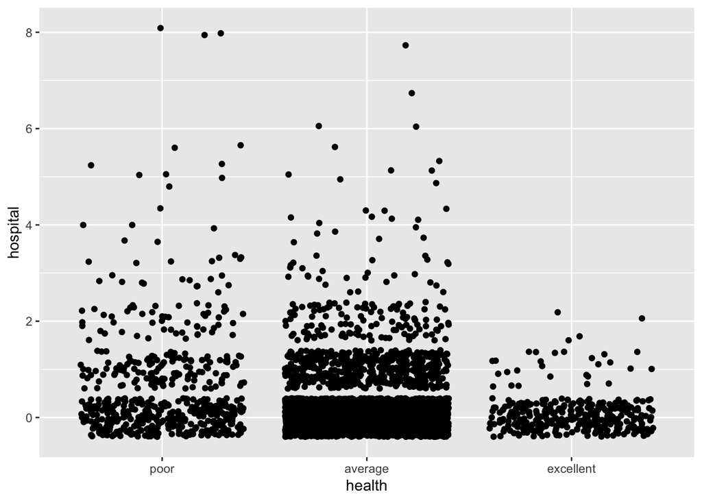

```r
ggplot(NMES1988, aes(health, hospital)) +
  geom_jitter()
```

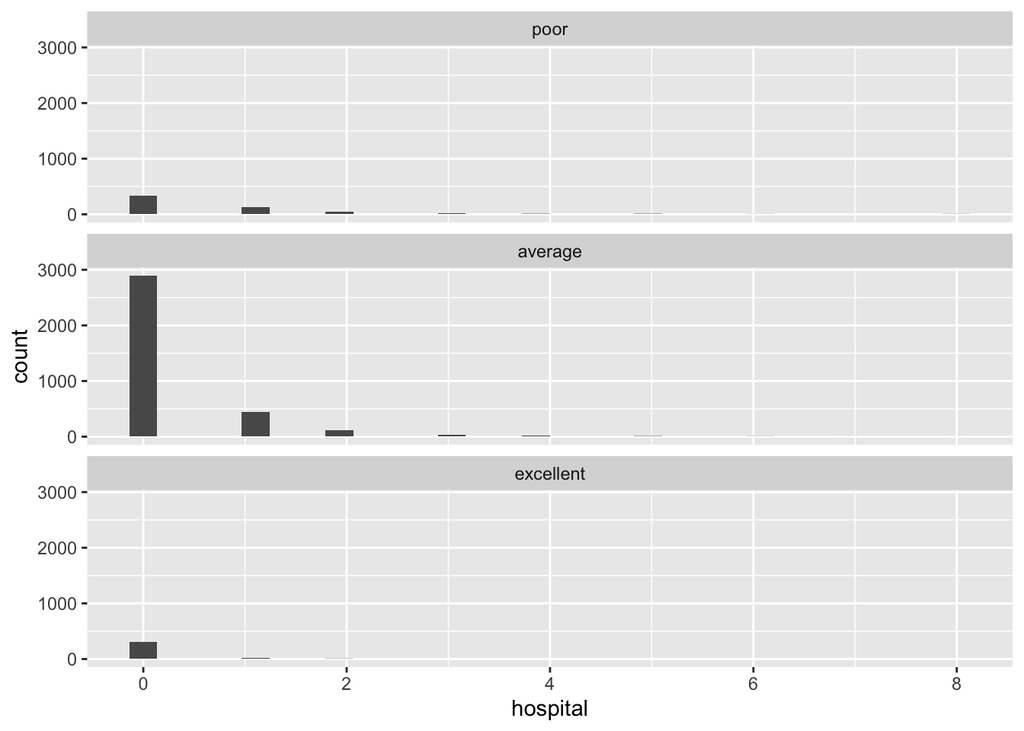

```r
ggplot(NMES1988, aes(hospital)) +
  geom_histogram() +
  facet_wrap(~health, nrow = 3)
```

Better perceived health has a negative association with number of hospitalizations.

Number of Chronic conditions (`chronic`):

```r
NMES1988 |>
  group_by(chronic) |>
  summarize(mean(hospital), sd(hospital), n())
```

```
## # A tibble: 9 × 4
##   chronic `mean(hospital)` `sd(hospital)` `n()`
##     <int>            <dbl>          <dbl> <int>
## 1       0            0.127          0.432  1025
## 2       1            0.194          0.542  1498
## 3       2            0.379          0.851   968
## 4       3            0.467          0.950   525
## 5       4            0.609          0.985   220
## 6       5            0.764          1.23    127
## 7       6            0.706          1.55     34
## 8       7            2.17           1.47      6
## 9       8            1.33           2.31      3
```

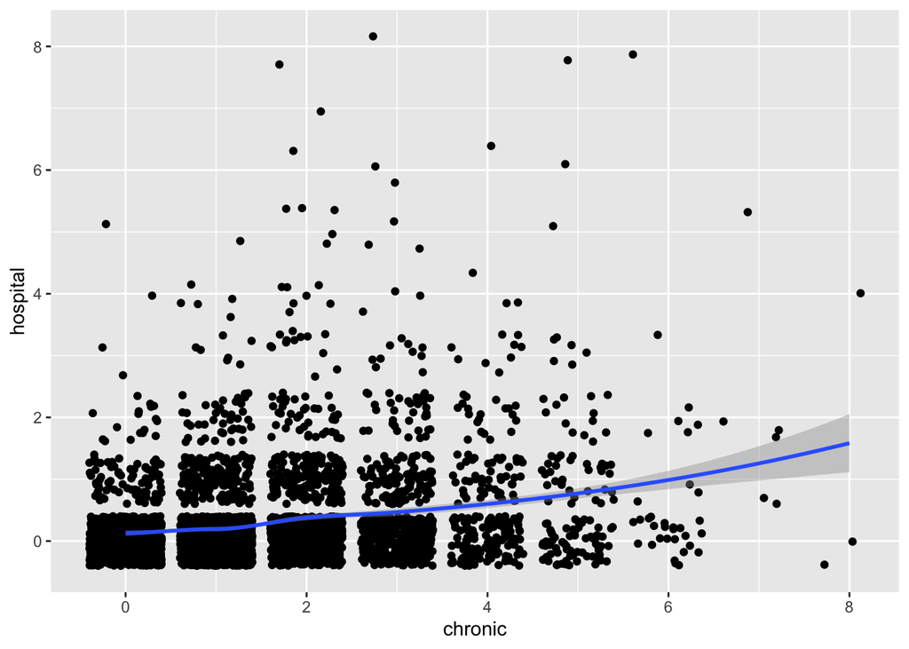

```r
ggplot(NMES1988, aes(chronic, hospital)) +
  geom_jitter() +
  geom_smooth(method = loess)
```

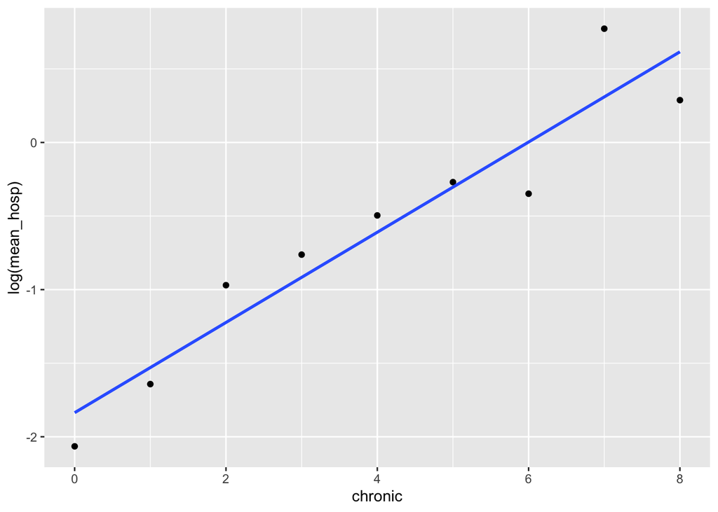

```r
NMES1988 |>
  group_by(chronic) |>
  summarize(mean_hosp = mean(hospital)) |>
  ggplot(aes(chronic,log(mean_hosp))) +
  geom_point() +
  geom_smooth(method = lm, se = FALSE)
```

Slight positive association betweeen number of chronice conditions and hospitalizations, although the number of people with more than 5 conditions is quite low, hence a lot of uncertanity in this range.

Limitations on activities of daily living (`adl`):

```r
NMES1988 |>
  group_by(adl) |>
  summarize(mean(hospital), sd(hospital), n())
```

```
## # A tibble: 2 × 4
##   adl     `mean(hospital)` `sd(hospital)` `n()`
##   <fct>              <dbl>          <dbl> <int>
## 1 normal             0.236          0.631  3507
## 2 limited            0.531          1.05    899
```

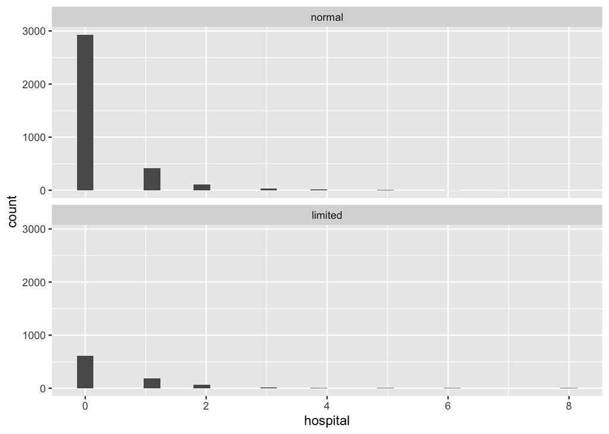

```r
ggplot(NMES1988, aes(hospital)) +
  geom_histogram() +
  facet_wrap(~adl, nrow = 2)
```

Average number of hospitalizations is about twice as high for people with limited ADL.

Income:

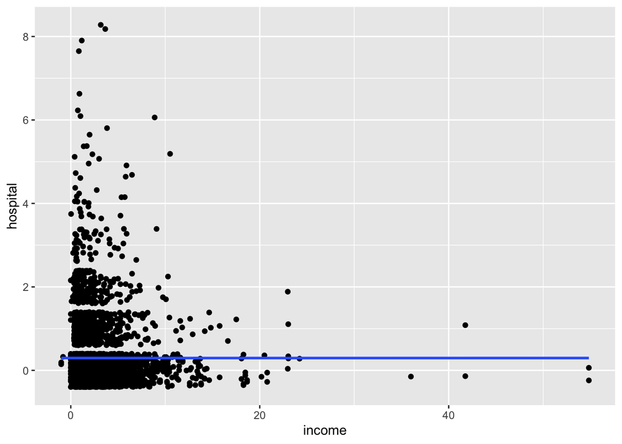

```r
ggplot(NMES1988, aes(income, hospital)) +
  geom_jitter() +
  geom_smooth()
```

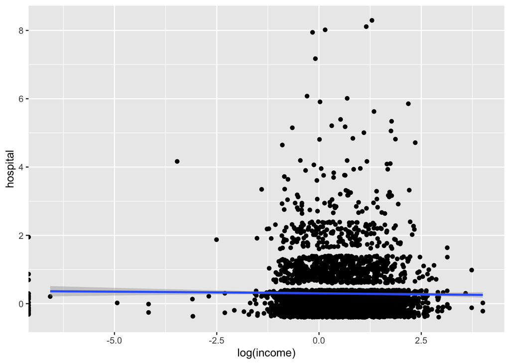

```r
ggplot(NMES1988, aes(log(income), hospital)) +
  geom_jitter() +
  geom_smooth()
```

Income doesn’t appear to have a very strong effect.

2. Which of our potential explanatory variables are related to *each other*? (We still need to think about issues of multicollinearity!)

```r
library(GGally)
```

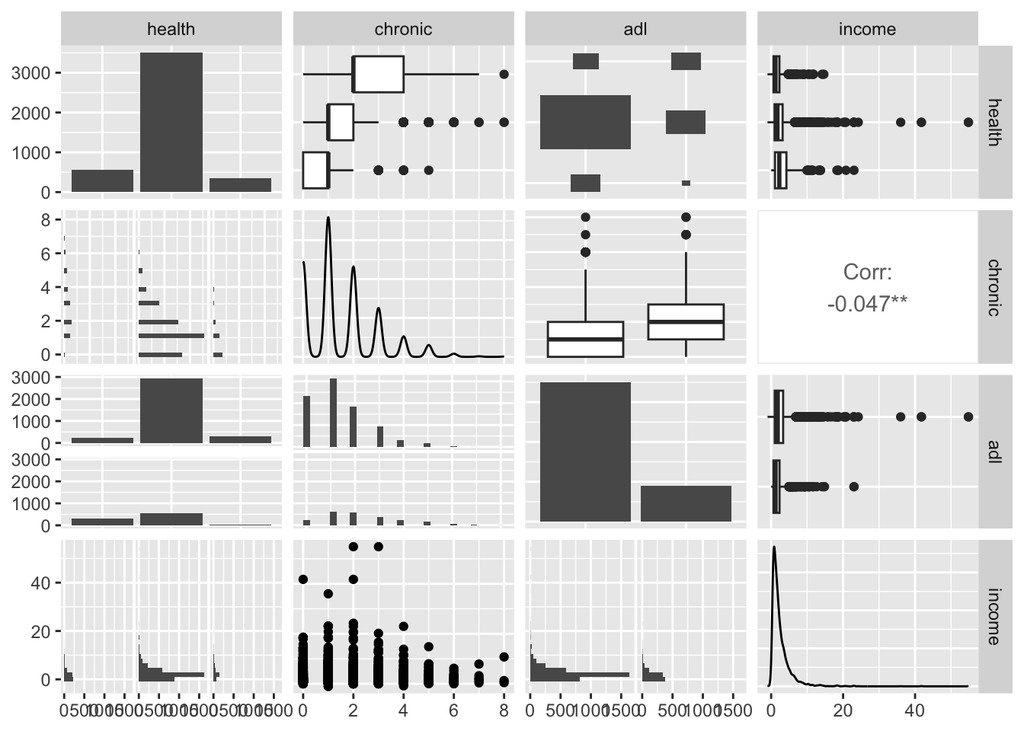

```r
NMES1988 |>
  select(health, chronic, adl, income) |>
  ggpairs()
```

Health statusts is related to number of chronic conditions and ADL.

3. Fit four separate Poisson regression models, each with a single predictor (health, chronic, adl, income) with `hospital` visits as the response. Which variable is by itself the best predictor? How do you know?

```r
hosp_health <- glm(hospital ~ health, data = NMES1988, family = poisson)
summary(hosp_health)
```

```
##
## Call:
## glm(formula = hospital ~ health, family = poisson, data = NMES1988)
##
## Coefficients:
##                 Estimate Std. Error z value Pr(>|z|)
## (Intercept)     -1.37524    0.03358 -40.958  < 2e-16 ***
## healthpoor       1.00611    0.06114  16.455  < 2e-16 ***
## healthexcellent -0.93613    0.17475  -5.357 8.47e-08 ***
## ---
## Signif. codes:  0 '***' 0.001 '**' 0.01 '*' 0.05 '.' 0.1 ' ' 1
##
## (Dispersion parameter for poisson family taken to be 1)
##
##     Null deviance: 4662.5  on 4405  degrees of freedom
## Residual deviance: 4366.8  on 4403  degrees of freedom
## AIC: 6319.3
##
## Number of Fisher Scoring iterations: 6
```

```r
hosp_chronic <- glm(hospital ~ chronic, data = NMES1988, family = poisson)
summary(hosp_chronic)
```

```
##
## Call:
## glm(formula = hospital ~ chronic, family = poisson, data = NMES1988)
##
## Coefficients:
##             Estimate Std. Error z value Pr(>|z|)
## (Intercept) -1.87402    0.04729  -39.63   <2e-16 ***
## chronic      0.34377    0.01640   20.96   <2e-16 ***
## ---
## Signif. codes:  0 '***' 0.001 '**' 0.01 '*' 0.05 '.' 0.1 ' ' 1
##
## (Dispersion parameter for poisson family taken to be 1)
##
##     Null deviance: 4662.5  on 4405  degrees of freedom
## Residual deviance: 4279.6  on 4404  degrees of freedom
## AIC: 6230.2
##
## Number of Fisher Scoring iterations: 6
```

```r
hosp_adl <- glm(hospital ~ adl, data = NMES1988, family = poisson)
summary(hosp_adl)
```

```
##
## Call:
## glm(formula = hospital ~ adl, family = poisson, data = NMES1988)
##
## Coefficients:
##             Estimate Std. Error z value Pr(>|z|)
## (Intercept) -1.44471    0.03477  -41.55   <2e-16 ***
## adllimited   0.81095    0.05749   14.11   <2e-16 ***
## ---
## Signif. codes:  0 '***' 0.001 '**' 0.01 '*' 0.05 '.' 0.1 ' ' 1
##
## (Dispersion parameter for poisson family taken to be 1)
##
##     Null deviance: 4662.5  on 4405  degrees of freedom
## Residual deviance: 4481.3  on 4404  degrees of freedom
## AIC: 6431.9
##
## Number of Fisher Scoring iterations: 6
```

```r
hosp_income <- glm(hospital ~ income, data = NMES1988, family = poisson)
summary(hosp_income)
```

```
##
## Call:
## glm(formula = hospital ~ income, family = poisson, data = NMES1988)
##
## Coefficients:
##             Estimate Std. Error z value Pr(>|z|)
## (Intercept) -1.18384    0.03764 -31.451   <2e-16 ***
## income      -0.01362    0.01052  -1.295    0.195
## ---
## Signif. codes:  0 '***' 0.001 '**' 0.01 '*' 0.05 '.' 0.1 ' ' 1
##
## (Dispersion parameter for poisson family taken to be 1)
##
##     Null deviance: 4662.5  on 4405  degrees of freedom
## Residual deviance: 4660.7  on 4404  degrees of freedom
## AIC: 6611.2
##
## Number of Fisher Scoring iterations: 6
```

```r
AIC(hosp_health, hosp_chronic, hosp_adl, hosp_income)
```

```
##              df      AIC
## hosp_health   3 6319.303
## hosp_chronic  2 6230.199
## hosp_adl      2 6431.865
## hosp_income   2 6611.226
```

Income does not have a significant relationship with number of hospitalizations (p = 0.195), but the other three variables do. The strongest association is probably with number of chronic conditions since this has the far lowest AIC.

4. Consider again the same list of variables: health, chronic, adl, and income, but this time use the response variable of `visits`. Do some EDA to determine which variables might be related to the response variable of `visits` (number of physician office visits).

Self-perceived health status (`health`):

```r
NMES1988 |>
  group_by(health) |>
  summarize(mean(visits), sd(visits), n())
```

```
## # A tibble: 3 × 4
##   health    `mean(visits)` `sd(visits)` `n()`
##   <fct>              <dbl>        <dbl> <int>
## 1 poor                8.90         9.12   554
## 2 average             5.51         6.31  3509
## 3 excellent           3.43         4.86   343
```

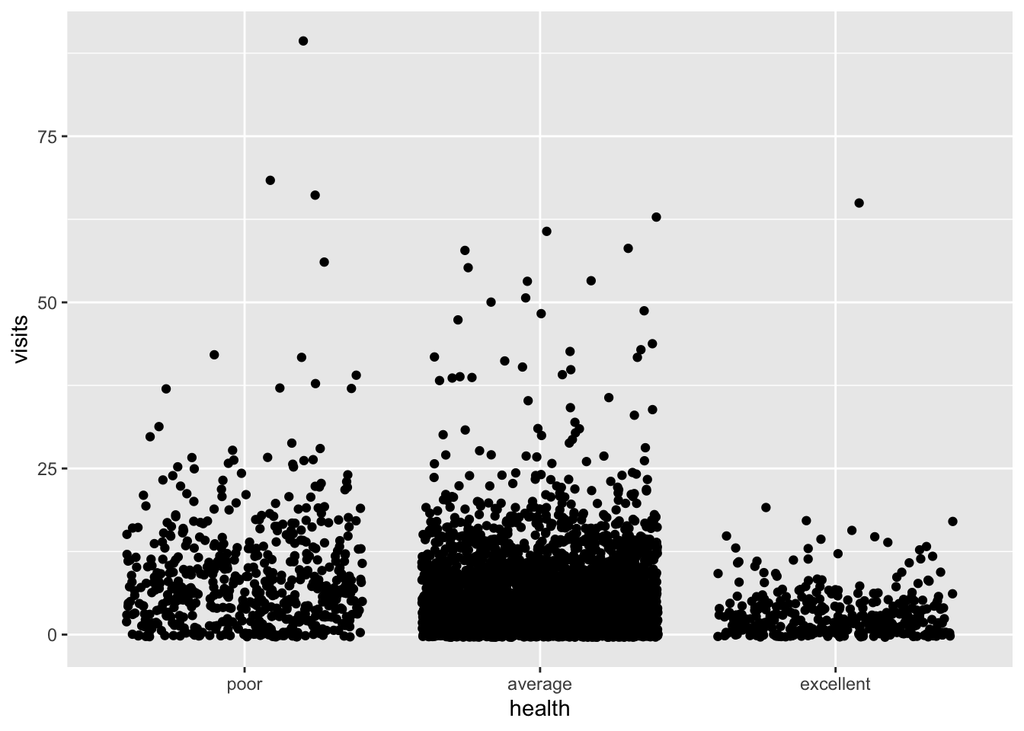

```r
ggplot(NMES1988, aes(health, visits)) +
  geom_jitter()
```

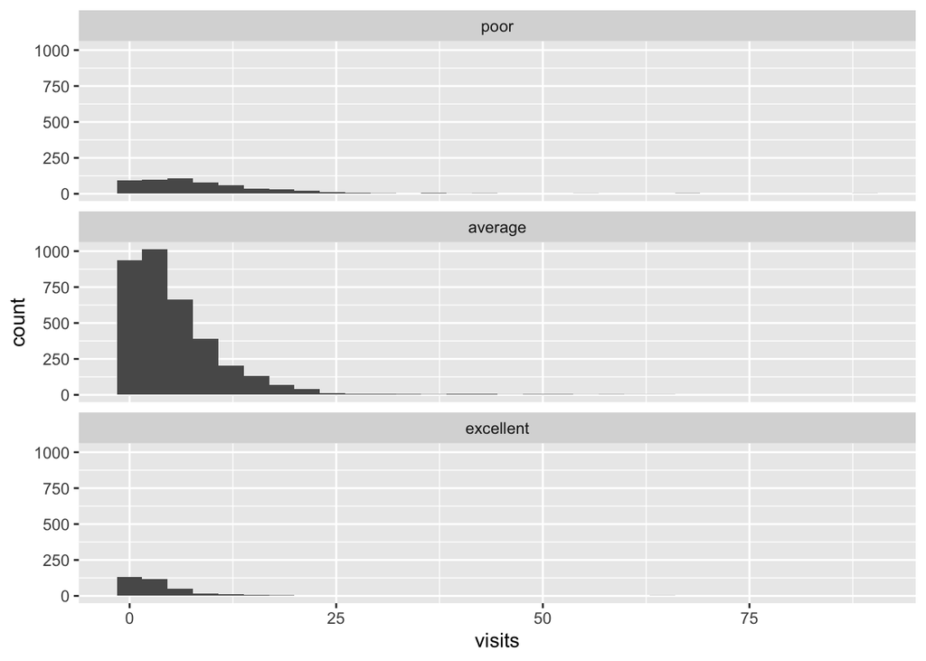

```r
ggplot(NMES1988, aes(visits)) +
  geom_histogram() +
  facet_wrap(~health, nrow = 3)
```

Better perceived health has a negative association with number of visits.

Number of Chronic conditions (`chronic`):

```r
NMES1988 |>
  group_by(chronic) |>
  summarize(mean(visits), sd(visits), n())
```

```
## # A tibble: 9 × 4
##   chronic `mean(visits)` `sd(visits)` `n()`
##     <int>          <dbl>        <dbl> <int>
## 1       0           3.38         5.00  1025
## 2       1           5.16         6.11  1498
## 3       2           6.87         7.46   968
## 4       3           7.34         6.71   525
## 5       4           9.29         8.66   220
## 6       5          10.2          8.27   127
## 7       6           9.65         7.75    34
## 8       7          12.5          8.76     6
## 9       8           2            3.46     3
```

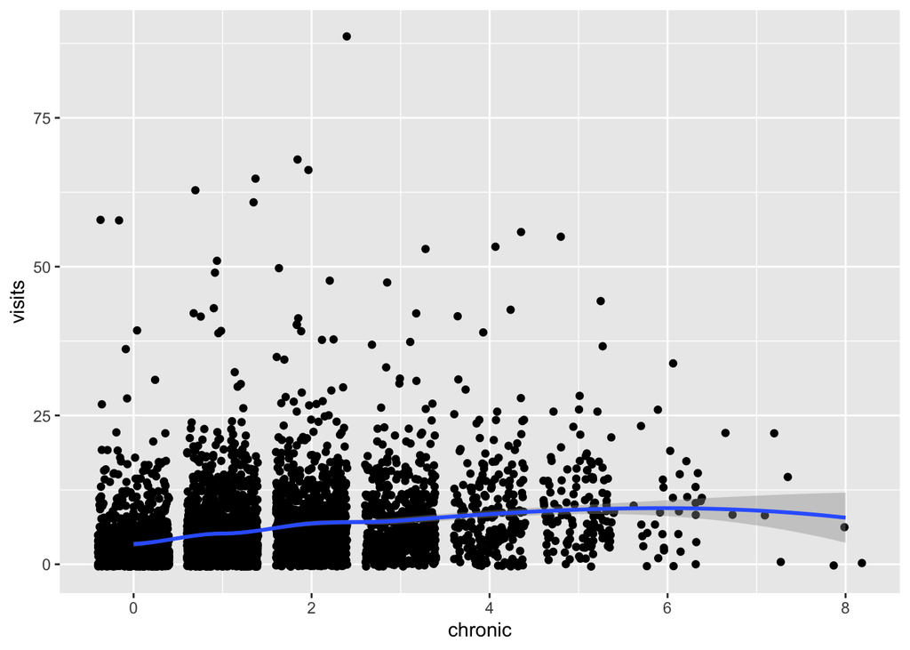

```r
ggplot(NMES1988, aes(chronic, visits)) +
  geom_jitter() +
  geom_smooth(method = loess)
```

Slight positive association betweeen number of chronic conditions and visits, although the number of people with more than 5 conditions is quite low, hence a lot of uncertanity in this range.

Limitations on activities of daily living (`adl`):

```r
NMES1988 |>
  group_by(adl) |>
  summarize(mean(visits), sd(visits), n())
```

```
## # A tibble: 2 × 4
##   adl     `mean(visits)` `sd(visits)` `n()`
##   <fct>            <dbl>        <dbl> <int>
## 1 normal            5.39         6.33  3507
## 2 limited           7.27         8.06   899
```

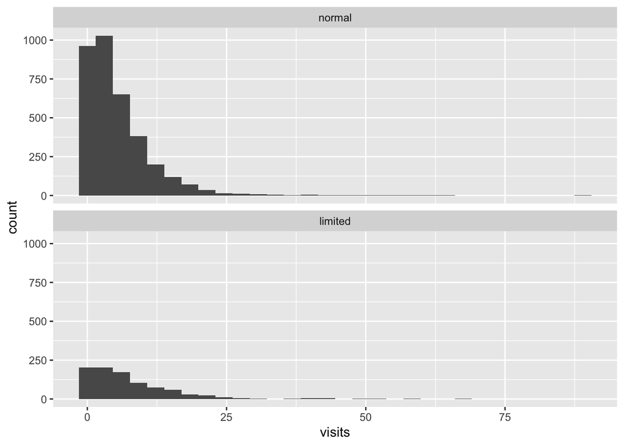

```r
ggplot(NMES1988, aes(visits)) +
  geom_histogram() +
  facet_wrap(~adl, nrow = 2)
```

Average number of visitsizations is about 35% higher for people with limited ADL. (7.3 visits vs 5.3 visits on average)

Income:

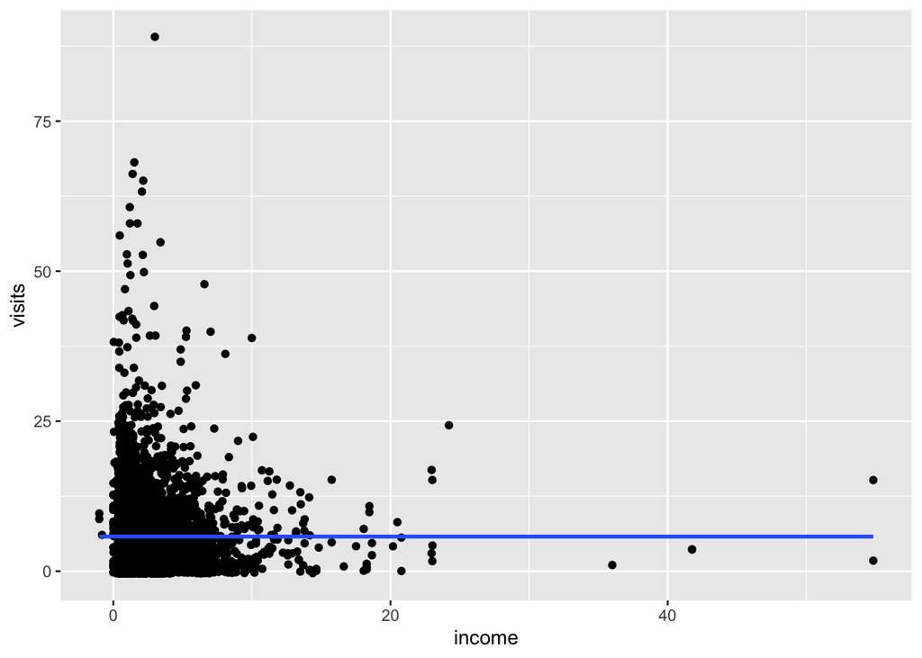

```r
ggplot(NMES1988, aes(income, visits)) +
  geom_jitter() +
  geom_smooth()
```

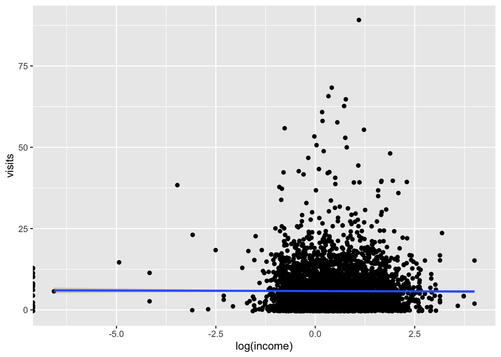

```r
ggplot(NMES1988, aes(log(income), visits)) +
  geom_jitter() +
  geom_smooth()
```

Income doesn’t appear to have a very strong effect.

## In class

In this section, we use `hospital` as the response variable.

5. Fit two different models with `hospital` as response that you think might be “good.” Which one is better? How do you know?

Based on EDA above, I’ll start with the model that has the three variables that were individually significant:

```r
hosp1 <- glm(hospital ~ health + chronic + adl, data = NMES1988, family = poisson)
summary(hosp1)
```

```
##
## Call:
## glm(formula = hospital ~ health + chronic + adl, family = poisson,
##     data = NMES1988)
##
## Coefficients:
##                 Estimate Std. Error z value Pr(>|z|)
## (Intercept)     -1.86886    0.04963 -37.659  < 2e-16 ***
## healthpoor       0.50990    0.06962   7.324 2.41e-13 ***
## healthexcellent -0.69419    0.17567  -3.952 7.76e-05 ***
## chronic          0.25029    0.01842  13.587  < 2e-16 ***
## adllimited       0.37392    0.06329   5.908 3.46e-09 ***
## ---
## Signif. codes:  0 '***' 0.001 '**' 0.01 '*' 0.05 '.' 0.1 ' ' 1
##
## (Dispersion parameter for poisson family taken to be 1)
##
##     Null deviance: 4662.5  on 4405  degrees of freedom
## Residual deviance: 4135.7  on 4401  degrees of freedom
## AIC: 6092.3
##
## Number of Fisher Scoring iterations: 6
```

This looks good, but I’ll try adding income, in case there is an association after accounting for everything else:

```r
hosp2 <- glm(hospital ~ health + chronic + adl + income, data = NMES1988, family = poisson)
summary(hosp2)
```

```
##
## Call:
## glm(formula = hospital ~ health + chronic + adl + income, family = poisson,
##     data = NMES1988)
##
## Coefficients:
##                  Estimate Std. Error z value Pr(>|z|)
## (Intercept)     -1.897214   0.055477 -34.198  < 2e-16 ***
## healthpoor       0.515231   0.069785   7.383 1.55e-13 ***
## healthexcellent -0.702687   0.175816  -3.997 6.42e-05 ***
## chronic          0.250301   0.018414  13.593  < 2e-16 ***
## adllimited       0.378488   0.063462   5.964 2.46e-09 ***
## income           0.010653   0.009142   1.165    0.244
## ---
## Signif. codes:  0 '***' 0.001 '**' 0.01 '*' 0.05 '.' 0.1 ' ' 1
##
## (Dispersion parameter for poisson family taken to be 1)
##
##     Null deviance: 4662.5  on 4405  degrees of freedom
## Residual deviance: 4134.5  on 4400  degrees of freedom
## AIC: 6093
##
## Number of Fisher Scoring iterations: 6
```

income isn’t significant, and the AIC went up. So the first model is better and income is not needed.

6. Interpret the intercept and at least one slope from your model.

```r
coef(hosp1) |> exp()
```

```
##     (Intercept)      healthpoor healthexcellent         chronic      adllimited
##       0.1542998       1.6651230       0.4994809       1.2844004       1.4534255
```

Average number of hospitalizations for a person with normal ADL, average self-perceived health, and 0 chronic conditions is 0.15 per year.

Patients in poor health have on average 66% more hospital visits than people with average health, after accounting for number of chronic conditions and ADL.

For each additional chronic condition, expected number of hospitalizations increases by 28%, after accounting for ADL and perceived health status.

7. Check the plot of deviance residuals vs fitted values for evidence of nonlinearity.

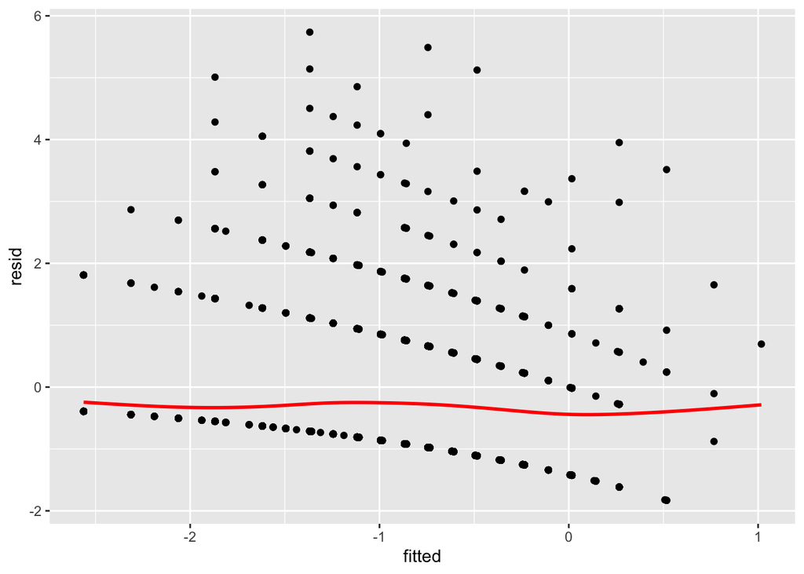

```r
hosp.pred <- data.frame(fitted = predict(hosp1),
                            resid = resid(hosp1))

ggplot(hosp.pred, aes(x = fitted, y = resid)) +
  geom_point() +
  geom_smooth(se = FALSE, color = "red")
```

*Looks good!*

8. Is there evidence of overdispersion?

```r
summary(hosp1)
```

```
##
## Call:
## glm(formula = hospital ~ health + chronic + adl, family = poisson,
##     data = NMES1988)
##
## Coefficients:
##                 Estimate Std. Error z value Pr(>|z|)
## (Intercept)     -1.86886    0.04963 -37.659  < 2e-16 ***
## healthpoor       0.50990    0.06962   7.324 2.41e-13 ***
## healthexcellent -0.69419    0.17567  -3.952 7.76e-05 ***
## chronic          0.25029    0.01842  13.587  < 2e-16 ***
## adllimited       0.37392    0.06329   5.908 3.46e-09 ***
## ---
## Signif. codes:  0 '***' 0.001 '**' 0.01 '*' 0.05 '.' 0.1 ' ' 1
##
## (Dispersion parameter for poisson family taken to be 1)
##
##     Null deviance: 4662.5  on 4405  degrees of freedom
## Residual deviance: 4135.7  on 4401  degrees of freedom
## AIC: 6092.3
##
## Number of Fisher Scoring iterations: 6
```

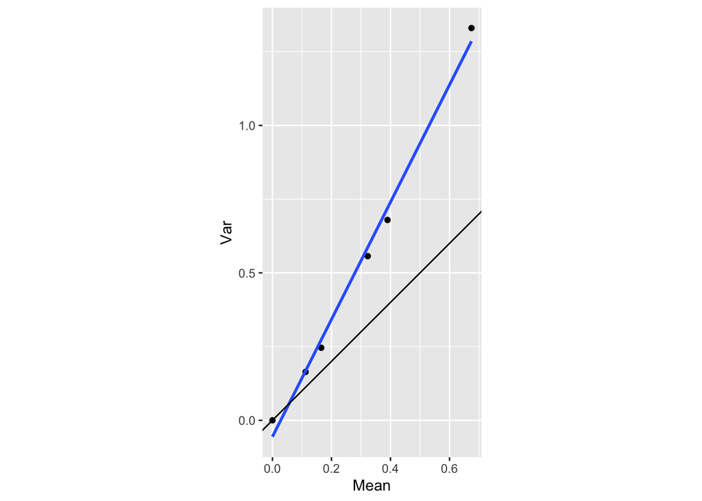

```r
NMES1988 %>%
  mutate(pred = predict(hosp1),
         grouping = cut_number(pred, 6)) %>%
  group_by(grouping) %>%
  summarize(Mean = mean(hospital),
            Var = var(hospital)) %>%
  ggplot(aes(Mean, Var)) +
  geom_point() +
  geom_smooth(method = lm, se = FALSE) +
  geom_abline(slope = 1, intercept = 0) +
  coord_equal()
```

Residual deviance (4135) is slightly lower than df (4401), so this suggests possible UNDER dispersion rather than over dispersion. The Variance is a bit higher than the mean in the mean vs variance plot… but overall this looks pretty good.

In the next section, we will use `visits` as the response variable, and start with the following model:

```r
visits1 <- glm(visits ~ health + chronic + adl + income,
               family = poisson,
               data = NMES1988)
summary(visits1)
```

```
##
## Call:
## glm(formula = visits ~ health + chronic + adl + income, family = poisson,
##     data = NMES1988)
##
## Coefficients:
##                  Estimate Std. Error z value Pr(>|z|)
## (Intercept)      1.420052   0.011953 118.804  < 2e-16 ***
## healthpoor       0.235449   0.017921  13.138  < 2e-16 ***
## healthexcellent -0.352553   0.030304 -11.634  < 2e-16 ***
## chronic          0.163730   0.004495  36.422  < 2e-16 ***
## adllimited       0.062647   0.015650   4.003 6.25e-05 ***
## income           0.007347   0.002044   3.594 0.000326 ***
## ---
## Signif. codes:  0 '***' 0.001 '**' 0.01 '*' 0.05 '.' 0.1 ' ' 1
##
## (Dispersion parameter for poisson family taken to be 1)
##
##     Null deviance: 26943  on 4405  degrees of freedom
## Residual deviance: 24365  on 4400  degrees of freedom
## AIC: 37152
##
## Number of Fisher Scoring iterations: 5
```

9. Is there evidence of overdispersion? How do you know?

*Yes, residual deviance (24365) is much larger than df (4400)*

10. Create a plot of mean vs variance. For this example, if you have a mutliple Poisson regression model you can do your grouping based on the predicted values. (see code below)

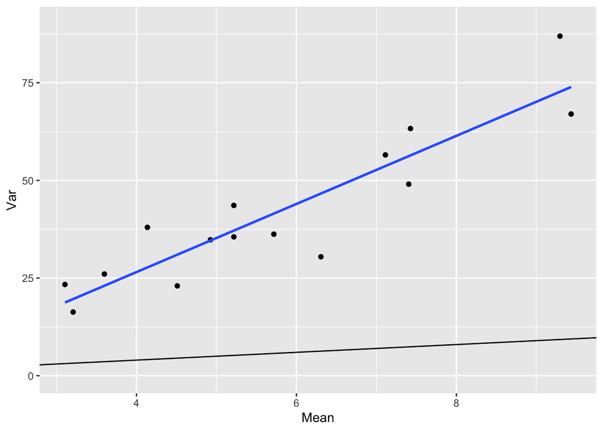

```r
NMES1988 %>%
  mutate(pred = predict(visits1),
         grouping = cut_number(pred, 15)) %>%
  group_by(grouping) %>%
  summarize(Mean = mean(visits),
            Var = var(visits )) %>%
  ggplot(aes(Mean, Var)) +
  geom_point() +
  geom_smooth(method = lm, se = FALSE) +
  geom_abline(slope = 1, intercept = 0) +
  coord_cartesian(ylim = c(0 , 90))
```

- Does the mean vs variance plot suggest overdispersion?

YES, the variance is about 6 or 7 times greater than the mean!

- Is the relationship of mean and variance linear, or curved?

LINEAR looks pretty good.

## Negative binomial vs. Quasi Poisson

In Quasi Poisson, we assume

$$Var(Y) = \phi\lambda$$

This is a LINEAR relationship between mean and variance. We can handle under or overdispersion by estimating $\phi$ as less than or greater than 1.

The parameter $\phi$ only affects the estimation of variance/standard error, so the predicted $\beta$ values will be the same as the ordinary Poisson model.

In Negative binomial, we let $E(Y) = \mu$. The overdispersion paramter $r$ is used in the relationship

$$Var(Y) = \mu + \mu^2/r$$

The paramter $r$ must be greater than 0. Thus this model only handles OVER dispersion, and a quadratic (curved) relationship between mean and variance is assumed.

The entire likelihood is different in Negative binomial compared to Poisson, and unusually large and small values (big residuals) have different weight. This means that the estimated $\beta$ values will be different than the ordinary Poisson model, although our interpretation of them is the same.

11. When the mean vs variance relationship is LINEAR, quasipoisson can work. When the mean vs variance is QUADRATIC (curved) we use the negative binomial model. Below, we fit both the quasipoisson and the negative binomial model. Compare the coefficient estimates and standard errors.

```r
visits1quas <- glm(formula = visits ~ health + chronic + adl + income, family = quasipoisson,
    data = NMES1988)

visits1nb <- MASS::glm.nb(visits ~ health + chronic + adl + income,
               data = NMES1988)

summary(visits1quas)$coef  %>% round(4)
```

```
##                 Estimate Std. Error t value Pr(>|t|)
## (Intercept)       1.4201     0.0320 44.3119   0.0000
## healthpoor        0.2354     0.0480  4.9004   0.0000
## healthexcellent  -0.3526     0.0812 -4.3392   0.0000
## chronic           0.1637     0.0121 13.5849   0.0000
## adllimited        0.0626     0.0420  1.4931   0.1355
## income            0.0073     0.0055  1.3405   0.1802
```

```r
summary(visits1nb)$coef %>% round(4)
```

```
##                 Estimate Std. Error z value Pr(>|z|)
## (Intercept)       1.3611     0.0291 46.7006   0.0000
## healthpoor        0.2530     0.0507  4.9905   0.0000
## healthexcellent  -0.3438     0.0622 -5.5252   0.0000
## chronic           0.1886     0.0124 15.2676   0.0000
## adllimited        0.0829     0.0413  2.0074   0.0447
## income            0.0104     0.0053  1.9589   0.0501
```

NOTE: we should test these borderline p-values with drop in deviance instead!

```r
# DO NOT EDIT THIS CHUNK
visits1nb2 <- MASS::glm.nb(visits ~ health + chronic + adl,
               data = NMES1988)
anova(visits1nb2, visits1nb, test = "Chisq")
```

```
## Likelihood ratio tests of Negative Binomial Models
##
## Response: visits
##                             Model    theta Resid. df    2 x log-lik.   Test
## 1          health + chronic + adl 1.125855      4401       -24568.10
## 2 health + chronic + adl + income 1.126974      4400       -24564.48 1 vs 2
##      df LR stat.    Pr(Chi)
## 1
## 2     1 3.623041 0.05698462
```

```r
summary(visits1nb2)
```

```
##
## Call:
## MASS::glm.nb(formula = visits ~ health + chronic + adl, data = NMES1988,
##     init.theta = 1.125854515, link = log)
##
## Coefficients:
##                 Estimate Std. Error z value Pr(>|z|)
## (Intercept)      1.38958    0.02549  54.518  < 2e-16 ***
## healthpoor       0.24692    0.05066   4.874 1.09e-06 ***
## healthexcellent -0.33606    0.06213  -5.409 6.32e-08 ***
## chronic          0.18845    0.01236  15.250  < 2e-16 ***
## adllimited       0.07636    0.04121   1.853   0.0639 .
## ---
## Signif. codes:  0 '***' 0.001 '**' 0.01 '*' 0.05 '.' 0.1 ' ' 1
##
## (Dispersion parameter for Negative Binomial(1.1259) family taken to be 1)
##
##     Null deviance: 5481.6  on 4405  degrees of freedom
## Residual deviance: 5041.6  on 4401  degrees of freedom
## AIC: 24580
##
## Number of Fisher Scoring iterations: 1
##
##
##               Theta:  1.1259
##           Std. Err.:  0.0306
##
##  2 x log-likelihood:  -24568.1030
```

```r
visits1nb3 <- MASS::glm.nb(visits ~ health + chronic,
               data = NMES1988)

summary(visits1nb3)
```

```
##
## Call:
## MASS::glm.nb(formula = visits ~ health + chronic, data = NMES1988,
##     init.theta = 1.124729448, link = log)
##
## Coefficients:
##                 Estimate Std. Error z value Pr(>|z|)
## (Intercept)      1.39808    0.02518  55.520  < 2e-16 ***
## healthpoor       0.27272    0.04873   5.597 2.19e-08 ***
## healthexcellent -0.34140    0.06210  -5.498 3.84e-08 ***
## chronic          0.19148    0.01222  15.676  < 2e-16 ***
## ---
## Signif. codes:  0 '***' 0.001 '**' 0.01 '*' 0.05 '.' 0.1 ' ' 1
##
## (Dispersion parameter for Negative Binomial(1.1247) family taken to be 1)
##
##     Null deviance: 5477.9  on 4405  degrees of freedom
## Residual deviance: 5041.8  on 4402  degrees of freedom
## AIC: 24582
##
## Number of Fisher Scoring iterations: 1
##
##
##               Theta:  1.1247
##           Std. Err.:  0.0306
##
##  2 x log-likelihood:  -24571.6350
```

```r
visits1nb31 <- MASS::glm.nb(visits ~ health + chronic,
               data = NMES1988)

summary(visits1nb31)
```

```
##
## Call:
## MASS::glm.nb(formula = visits ~ health + chronic, data = NMES1988,
##     init.theta = 1.124729448, link = log)
##
## Coefficients:
##                 Estimate Std. Error z value Pr(>|z|)
## (Intercept)      1.39808    0.02518  55.520  < 2e-16 ***
## healthpoor       0.27272    0.04873   5.597 2.19e-08 ***
## healthexcellent -0.34140    0.06210  -5.498 3.84e-08 ***
## chronic          0.19148    0.01222  15.676  < 2e-16 ***
## ---
## Signif. codes:  0 '***' 0.001 '**' 0.01 '*' 0.05 '.' 0.1 ' ' 1
##
## (Dispersion parameter for Negative Binomial(1.1247) family taken to be 1)
##
##     Null deviance: 5477.9  on 4405  degrees of freedom
## Residual deviance: 5041.8  on 4402  degrees of freedom
## AIC: 24582
##
## Number of Fisher Scoring iterations: 1
##
##
##               Theta:  1.1247
##           Std. Err.:  0.0306
##
##  2 x log-likelihood:  -24571.6350
```

```r
anova(visits1nb3, visits1nb2, test = "Chisq")
```

```
## Likelihood ratio tests of Negative Binomial Models
##
## Response: visits
##                    Model    theta Resid. df    2 x log-lik.   Test    df
## 1       health + chronic 1.124729      4402       -24571.63
## 2 health + chronic + adl 1.125855      4401       -24568.10 1 vs 2     1
##   LR stat.    Pr(Chi)
## 1
## 2 3.532098 0.06019159
```

```r
# EDA Suggests no relationship as well.
NMES1988 %>%
  group_by(adl) %>%
  summarize(mean(visits), sd(visits), median(visits))
```

```
## # A tibble: 2 × 4
##   adl     `mean(visits)` `sd(visits)` `median(visits)`
##   <fct>            <dbl>        <dbl>            <int>
## 1 normal            5.39         6.33                4
## 2 limited           7.27         8.06                5
```

```r
cor(NMES1988$visits, NMES1988$income)
```

```
## [1] -0.004951069
```

*What you should see above: The linear relationship of mean and variance suggests a quasi poisson model would be appropriate. If you really want to have a likelihood based model (for example, if you want to do lots of LRT/DDTs to compare nested models), you might still go with the negative binomial. Though the assumption is a quadratic relationship, it can do ok for a linear relationship too. In this case, either model is justifiable, and we come to similar overall conclusions.*

12. A different group of researchers proposes the following model instead, and create the mean vs variance plot. Which type of overdispersed model seems more appropriate: quasipoisson or negative binomial?

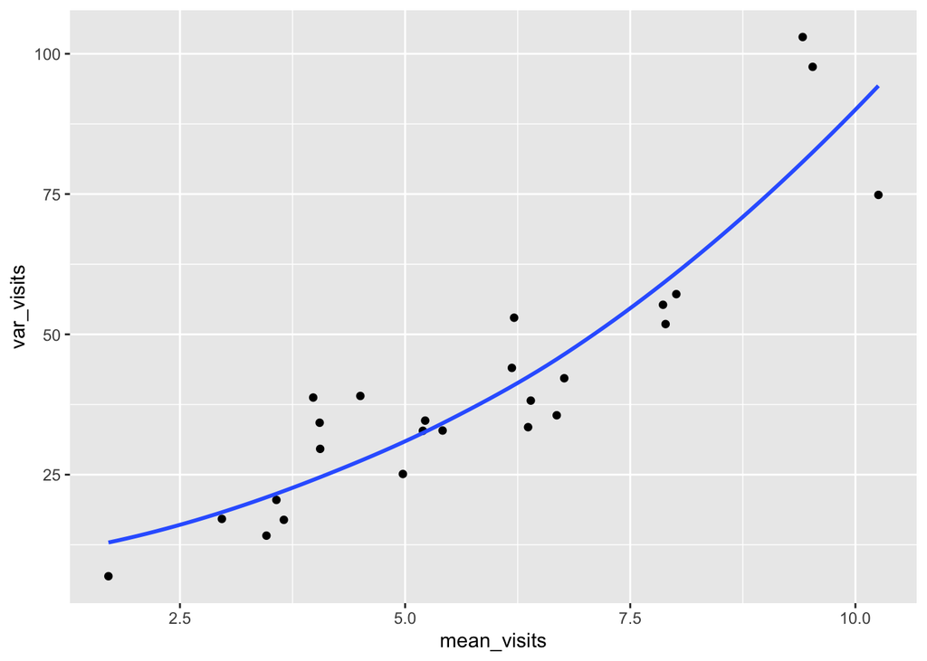

```r
visits2 <- glm(formula = visits ~ insurance + health + chronic +
    afam + school + age,
    family = poisson,
    data = NMES1988)

# CUT/GROUP by the PREDICTED VALUES
NMES1988 %>%
  mutate(pred = predict(visits2),
         group = cut_number(pred, 25)) %>%
  group_by(group) %>%
  summarize(mean_visits = mean(visits),
            var_visits = var(visits)) %>%
  ggplot(aes(mean_visits, var_visits)) +
  geom_point() +
  geom_smooth(span = 2, se = FALSE)
```

*The relationship of mean and variance is clearly quadratic!*

13. Here again we fit both. What differences do you notice?

```r
visits2quas <- glm(formula = visits ~ insurance + health + chronic +
    afam + school + age,
    family = quasipoisson,
    data = NMES1988)

visits2nb <- MASS::glm.nb(formula = visits ~ insurance + health + chronic +
    afam + school + age,
    data = NMES1988)


summary(visits2quas)$coef %>% round(4)
```

```
##                 Estimate Std. Error t value Pr(>|t|)
## (Intercept)       1.2158     0.2132  5.7018   0.0000
## insuranceyes      0.2004     0.0459  4.3694   0.0000
## healthpoor        0.3222     0.0462  6.9750   0.0000
## healthexcellent  -0.3846     0.0799 -4.8132   0.0000
## chronic           0.1685     0.0118 14.2680   0.0000
## afamyes          -0.0397     0.0583 -0.6803   0.4964
## school            0.0248     0.0049  5.0208   0.0000
## age              -0.0265     0.0267 -0.9929   0.3208
```

```r
summary(visits2nb)$coef %>% round(4)
```

```
##                 Estimate Std. Error z value Pr(>|z|)
## (Intercept)       0.9802     0.1980  4.9511   0.0000
## insuranceyes      0.2329     0.0414  5.6220   0.0000
## healthpoor        0.3693     0.0489  7.5572   0.0000
## healthexcellent  -0.3840     0.0618 -6.2145   0.0000
## chronic           0.1953     0.0121 16.1237   0.0000
## afamyes          -0.0439     0.0521 -0.8426   0.3994
## school            0.0262     0.0045  5.7665   0.0000
## age              -0.0074     0.0249 -0.2969   0.7665
```

```r
summary(visits2quas)
```

```
##
## Call:
## glm(formula = visits ~ insurance + health + chronic + afam +
##     school + age, family = quasipoisson, data = NMES1988)
##
## Coefficients:
##                  Estimate Std. Error t value Pr(>|t|)
## (Intercept)      1.215793   0.213228   5.702 1.26e-08 ***
## insuranceyes     0.200411   0.045867   4.369 1.27e-05 ***
## healthpoor       0.322214   0.046196   6.975 3.52e-12 ***
## healthexcellent -0.384621   0.079909  -4.813 1.53e-06 ***
## chronic          0.168543   0.011813  14.268  < 2e-16 ***
## afamyes         -0.039656   0.058295  -0.680    0.496
## school           0.024779   0.004935   5.021 5.35e-07 ***
## age             -0.026528   0.026719  -0.993    0.321
## ---
## Signif. codes:  0 '***' 0.001 '**' 0.01 '*' 0.05 '.' 0.1 ' ' 1
##
## (Dispersion parameter for quasipoisson family taken to be 6.952921)
##
##     Null deviance: 26943  on 4405  degrees of freedom
## Residual deviance: 23868  on 4398  degrees of freedom
## AIC: NA
##
## Number of Fisher Scoring iterations: 5
```

*The difference in results between the two models is bigger. We should trust the Negative Binomial results here!*

14. We can also examine the fitted vs deviance residuals for the poisson and the negative binomial models. Why are the deviance residuals so much smaller for the negative binomial model? How might we adjust our visualization for a better comparison?

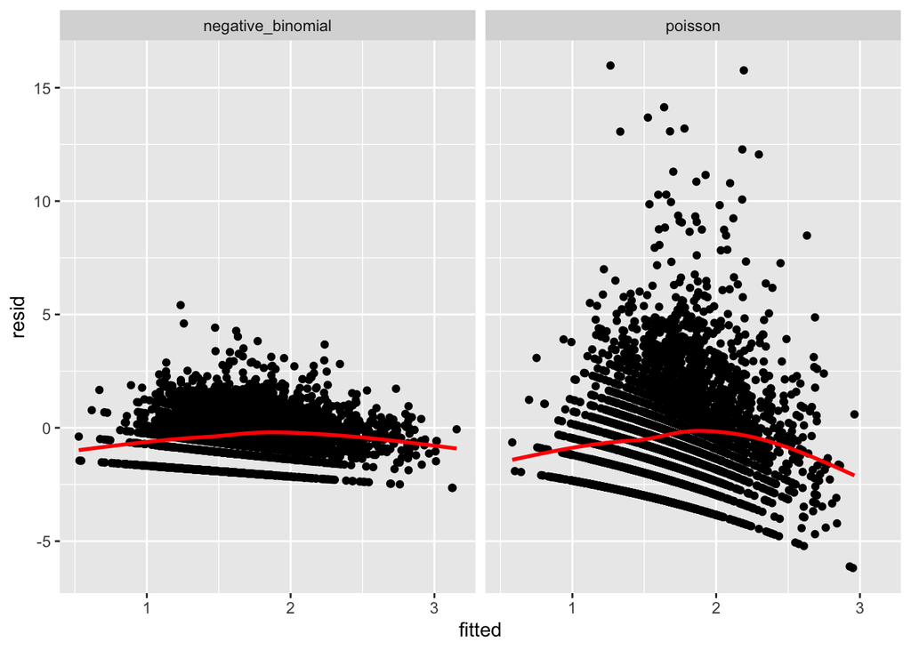

```r
fitdeviance <- data.frame(fitted = predict(visits2),
                            resid = resid(visits2),
                     model = "poisson") %>%
  bind_rows(data.frame(fitted = predict(visits2nb),
                            resid = resid(visits2nb),
                     model = "negative_binomial"))

ggplot(fitdeviance, aes(x = fitted, y = resid)) +
  geom_point() +
  geom_smooth(se = FALSE, color = "red", span = 2) +
  facet_wrap(~model)
```

The poisson are not really scaled properly by variance. Divide those deviance residuals by sqrt(phi).

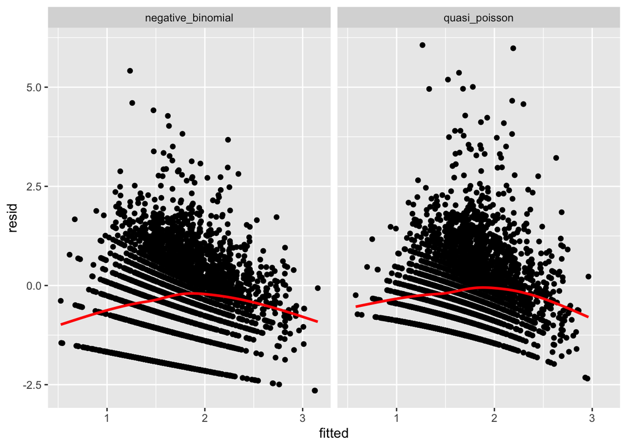

```r
fitdeviance <- data.frame(fitted = predict(visits2),
                            resid = resid(visits2)/sqrt(6.95),
                     model = "quasi_poisson") %>%
  bind_rows(data.frame(fitted = predict(visits2nb),
                            resid = resid(visits2nb),
                     model = "negative_binomial"))

ggplot(fitdeviance, aes(x = fitted, y = resid)) +
  geom_point() +
  geom_smooth(se = FALSE, color = "red", span = 2) +
  facet_wrap(~model)
```

Note that in both plots we still see some curvature… maybe quadratic terms could be used for some of the continuous variables?

Note also that the deviances are not exactly the same… when the fitted values are large, the deviances for the negative binomial model are not as great as the deviances from the quasipoisson. In other words, since more variability is expected here, the observations are not counted as so unusual and have less deviance.

15. Which model is preferred: visits1 or visits2?

```r
AIC(visits1nb, visits2nb)
```

```
##           df      AIC
## visits1nb  7 24578.48
## visits2nb  9 24484.27
```

*We can use AIC if we use the negative binomial models. Visits2 has the lower AIC so is preferred. (Note however we still could probably make an even better model!)*

Important notes:

- To compare two NESTED quasipoisson models, we can use anova(m1, m1, test = “F”). This an approximation to the likelihood ratio test. (Can’t use LRT because it is not a true likelihood!)
- The negative binomial model uses a true likelihood. To compare two NESTED negative binomial models, we can use anova(m1, m1, test = “Chisq”) just as with Poisson or other models! We can also compare AICs.
- The QuasiPoisson model also works in cases of underdispersion. We will see the Residual deviance as LESS than the df in the summary output and estimate $\phi < 1$.
- The Negative Binomial model can only handle OVERdispersion.
- We can compare the Negative Binomial model to the Poisson with AIC since they are both likelihood based. If the Negative Binomial model has lower AIC, this suggests there is overdispersion! However, we cannot use AIC to determine *which* overdispersed model is preferred (Negative Binomial or quasi-Poisson) since the quasi-Poisson is not likelihood-based and therefore has no AIC.